[Ghezae Fisseha](https://gafstar.github.io/)

# What is Cohort Analysis?

June 22, 2021 in [Analytics](https://gafstar.github.io/categories/analytics)

In this post you will discover:

- What cohort analysis is.
- Why cohort is useful.
- Stages of performing proper cohort analysis.
- A step by step cohort analysis of an e-Commerce data using python.

First, let's begin by defining what cohort mean. The word **cohort** is derived from Latin **cohors** meaning an enclosure or enclosed group. In digital analytics context it means a group of customers that share something in common. This refers to a groupo of users who have similar characteristics or experiences within a defined time-span. Therefore, cohort analysis is a type of behavioral analytics that breaks the dataset into groups before conducting analysis. The grouping metric depends on the question you want to answer to. Cohort analysis is very popular in e-commerce, SaaS and Gaming platforms. It helps companies see patterns clearly across time, hence, a company can adapt and tailor it service to those specific cohorts. Time span is an important part of the analysis. We want to understand how the group behaves as time progresses. We can use different levels of time granularity, however, weekly and monthly are two most common time spans used in cohort analysis.

In e-Commerce or SaaS, a company may only be interested in customers who churned a week after making their first purchase, which is an example specific of cohort analysis. A software developer may only care about new user sign ups after upgrading the user interface for sign up form. A company may want to assess if users coming via referral from certain advertizing platform are making more sign ups or purchases. This would help them identify which user interface change or marketing strategy is making impacts.

### Why is cohort useful?

Cohort Analysis is beneficial for a company to that rely on long-term user engagment through customer relationship manager CRM. Here are some ways cohort analysis can be used.

1. **Understanding business cycles**: It helps to proactively plan for customer aqcuisition or customer behaviour.
2. **Experimenting**: It can be used with experimenting a cross-section study like A/B test so that helps you optimize your study. For example, if you run an A/B tst for a feature change by hypothesizing that blue layout (A group) causes more users to convert than a green layout (B group). You discover that that blue layout indeed causes more sign up than a green layout. Let's say you decide to do cohort analysis to see if those changes reflect across all geographies. You segment your user by month and zipcode and notice that for some regions the result was inconclusive. You will then investigate further as to why would be the case.
3. **Learn about user shopping habits**: This will help understand what are the attributes for user/customer who come to the site for the first time? or how are new user/customers different from returning customers? For instance, for eCommerce companies, you may dive in to see the quantity of purchases made, revenue from those items, types of items...etc to learn the shopping habits.
4. **Helps you understand customer retention and/or churn**: cohort analysis is very handy to analyse customer churn or retention. This post is dedicated to cohort analysis on user retention for an online retail company.
5. **Calculate customer lifetime value**: Because, you don't know how long each relationship with a customer will be. Therefore, depending how long each relationship will be, you can make a good estimate and state CLV as a periodic value. For example, the cohort analysis on this post is about 13 months long, therefore, we can say "this customers 3-month CLV is \$XXXX".
6. **Provides actionable information**. Having the cohorts information allows the ability to drill down to the users of specific cohorts at specific time period to gain better understanding of their behavior. Each new group provides the opportunity to start fresh set of users which allows us to look at only the data that is relevant to the specific question.

#### In order to perform a proper cohort analysis, there are four stages:

1. **Determine what question you want to answer:** The main goal of doing cohort analysis is to come up with actionable information to act on to improve the business, user experience, revenue, retention, customer acquisition ...ect. To ensure that you have have to ask teh right question
2. **Define the metrics that will be able to help you answer the question**. A proper cohort analysis requires the identification of an event, such us a user checking out, and specific events like total quatity or purchase value of each item.
3. **Define the specific cohort that are relevant**. You can either analyse all the users and target them or perform attribute contribution in order to find the relevant differences between each of them and ultimately discover and explain their behavior as specific cohort. For instance, you can split users as unique or repeat as each group differ in actions, pricing, subscription type. Repeat buyers or premium subscribers might be a large chunk of a company's revenue than first time basics users. Therefore, in such cases, performing split cohort analysis might give you an insight into customer spending in relation to the company revenue.
4. **Perform the cohort analysis**. You can use data visualization like line charts or heatmaps that will to understand your analysis.

### A step by step cohort analysis of an e-Commerce data

We will use a dataset downloaded from [UCI Machine Learning Repository](https://archive.ics.uci.edu/ml/index.php) . This repository contains different types of open source dataset.

#### Data Set Information:

This is a transnational data set which contains all the transactions occurring between 01/12/2010 and 09/12/2011 for a UK-based and registered non-store online retail.The company mainly sells unique all-occasion gifts. Many customers of the company are wholesalers.

#### Attribute Information:

- **InvoiceNo** Invoice number. Nominal, a 6-digit integral number uniquely assigned to each transaction. If this code starts with letter 'c', it indicates a cancellation.
- **StockCode** Product (item) code. Nominal, a 5-digit integral number uniquely assigned to each distinct product.
- **Description** Product (item) name. Nominal.
- **Quantity** The quantities of each product (item) per transaction. Numeric.
- **InvoiceDate** Invice Date and time. Numeric, the day and time when each transaction was generated.
- **UnitPrice** Unit price. Numeric, Product price per unit in sterling.
- **CustomerID** Customer number. Nominal, a 5-digit integral number uniquely assigned to each customer.
- **Country** Country name. Nominal, the name of the country where each customer resides.

```python
# numpy and pandas for data manipulation
import numpy as np
import pandas as pd

# datetime for date formatting
import datetime as dt

# matplotlib and seaborn for plotting
import matplotlib.pyplot as plt
import seaborn as sns
```

```python
df = pd.read_excel('Online Retail.xlsx')
```

```python
print(df.shape)
df.head()
```

```
(541909, 8)
```

|  | InvoiceNo | StockCode | Description | Quantity | InvoiceDate | UnitPrice | CustomerID | Country |
| --- | --- | --- | --- | --- | --- | --- | --- | --- |
| 0 | 536365 | 85123A | WHITE HANGING HEART T-LIGHT HOLDER | 6 | 2010-12-01 08:26:00 | 2.55 | 17850.0 | United Kingdom |
| 1 | 536365 | 71053 | WHITE METAL LANTERN | 6 | 2010-12-01 08:26:00 | 3.39 | 17850.0 | United Kingdom |
| 2 | 536365 | 84406B | CREAM CUPID HEARTS COAT HANGER | 8 | 2010-12-01 08:26:00 | 2.75 | 17850.0 | United Kingdom |
| 3 | 536365 | 84029G | KNITTED UNION FLAG HOT WATER BOTTLE | 6 | 2010-12-01 08:26:00 | 3.39 | 17850.0 | United Kingdom |
| 4 | 536365 | 84029E | RED WOOLLY HOTTIE WHITE HEART. | 6 | 2010-12-01 08:26:00 | 3.39 | 17850.0 | United Kingdom |

The data contains 541909 observations (each row represents a separate transaction) and 8 variables.

#### Data Preparation

From the attribute information the field InvoiceNo contains values that start with the letter 'c' referring to cancelled transactions. We will remove those values to clean up the data a bit.

```python
df2 = df[~df.InvoiceNo.astype(str).str.contains('C', na=False)]
print(df2.shape)
print(f'Total cancelled transactions: {df.shape[0] - df2.shape[0]}')
```

```
(532621, 8)
Total cancelled transactions: 9288
```

We can see that there are 9288 cancelled transactions. We don't need cancelled trasactions for our cohort analysis. We only care about those who didn't cancel the transaction. Now let's see if there are any missing values in our data.

### Check for missing values

```python
# check for missing values in each of the columns
df.isnull().sum()
```

```
InvoiceNo           0
StockCode           0
Description      1454
Quantity            0
InvoiceDate         0
UnitPrice           0
CustomerID     135080
Country             0
dtype: int64
```

Two features, `Description` and `CustomerID` have missing values. `CustomerId` field has about 135080 (roughly 25%) missing values. That is a lot of information missing from the table. We are going to drop missing values in this case, because the feature that contains the missing values is a unique identifier for the customer. If `CustomerID` field has missing values, it is very difficult to impute those values from the other features in the table. In real world scenario, we would probably have other tables in our database that contains information about `InvoiceNo` and `CustomerID`and we would join those with the current online retail table to fill up the missing info. However, since we don't have that information at hand at this point, we proceed our analysis by omitting records that has missing `CustomerID`.

```python
# Drop Missing records
df = df.dropna(subset=['CustomerID'])
df.isnull().sum()
```

```
InvoiceNo      0
StockCode      0
Description    0
Quantity       0
InvoiceDate    0
UnitPrice      0
CustomerID     0
Country        0
dtype: int64
```

That looks great now without any missing values. By removing the missing `CustomerID` fields also removed the `Description` records.

### Check for duplicates

```python
# check duplicates
df.duplicated().sum()
```

```
5225
```

We see there are 5225 (~1%) duplicates in our data. We need to remove those as well because including it will inflate the retention count for each cohort. This would introduce type 1 error (false positive) to our retention analysis, hence, it is very important to remove duplicates at this point.

```python
# drop duplicates
df = df.drop_duplicates()

# assert for dropped duplicates. As long as it doesn't raise exception error, we are fine
assert(df.duplicated().sum() == 0)
```

Alright, now we have removed our missing values and duplicates, lets check basic summary statistics for the numerical features. This will help us to spot check anomalies or skewness in the distribution of those numerical features.

```python
df.describe()
```

|  | Quantity | UnitPrice | CustomerID |
| --- | --- | --- | --- |
| count | 401604.000000 | 401604.000000 | 401604.000000 |
| mean | 12.183273 | 3.474064 | 15281.160818 |
| std | 250.283037 | 69.764035 | 1714.006089 |
| min | -80995.000000 | 0.000000 | 12346.000000 |
| 25% | 2.000000 | 1.250000 | 13939.000000 |
| 50% | 5.000000 | 1.950000 | 15145.000000 |
| 75% | 12.000000 | 3.750000 | 16784.000000 |
| max | 80995.000000 | 38970.000000 | 18287.000000 |

Here we notice that the min of quantity is negative and the minimum of unit price is zero. It doesn't make sense to have a negative quantity and zero unit price. So, lets do more cleaning by onnly considering the values for `Quantity`and `UnitPrice` to be greater than zero.

```python
# filter values greater than zero
df = df[(df['Quantity']>0) & (df['UnitPrice'] > 0)]
df.describe()
```

|  | Quantity | UnitPrice | CustomerID |
| --- | --- | --- | --- |
| count | 392692.000000 | 392692.000000 | 392692.000000 |
| mean | 13.119702 | 3.125914 | 15287.843865 |
| std | 180.492832 | 22.241836 | 1713.539549 |
| min | 1.000000 | 0.001000 | 12346.000000 |
| 25% | 2.000000 | 1.250000 | 13955.000000 |
| 50% | 6.000000 | 1.950000 | 15150.000000 |
| 75% | 12.000000 | 3.750000 | 16791.000000 |
| max | 80995.000000 | 8142.750000 | 18287.000000 |

Now, it is looks better. We no longer have negative and zero as minimum values. You can notice that by removing those outliers, the standard deviation of `Quantity` and `UnitPrice` shrunk from 250 to 180 and 69 to 22, respectively. This means the narrower the confidence interval, the more precise our estimate is for `Quantity` and `UnitPrice`.

Moving on with our data preparation, we will create two additional new features from the `InvoiceDate` field. `InvoiceDate` data type is datetime, however, we will create two new features `InvoiceMonth` and `CohortMonth` as date fields.

```python
# extract the month from the datetime field and create two new columns InvoiceMonth and CohortMonth
def get_month(x):
    return dt.datetime(x.year, x.month, 1)
df['InvoiceMonth'] = df['InvoiceDate'].apply(get_month)
df['CohortMonth'] = df.groupby('CustomerID')['InvoiceMonth'].transform('min')
df.head()
```

|  | InvoiceNo | StockCode | Description | Quantity | InvoiceDate | UnitPrice | CustomerID | Country | InvoiceMonth | CohortMonth |
| --- | --- | --- | --- | --- | --- | --- | --- | --- | --- | --- |
| 0 | 536365 | 85123A | WHITE HANGING HEART T-LIGHT HOLDER | 6 | 2010-12-01 08:26:00 | 2.55 | 17850.0 | United Kingdom | 2010-12-01 | 2010-12-01 |
| 1 | 536365 | 71053 | WHITE METAL LANTERN | 6 | 2010-12-01 08:26:00 | 3.39 | 17850.0 | United Kingdom | 2010-12-01 | 2010-12-01 |
| 2 | 536365 | 84406B | CREAM CUPID HEARTS COAT HANGER | 8 | 2010-12-01 08:26:00 | 2.75 | 17850.0 | United Kingdom | 2010-12-01 | 2010-12-01 |
| 3 | 536365 | 84029G | KNITTED UNION FLAG HOT WATER BOTTLE | 6 | 2010-12-01 08:26:00 | 3.39 | 17850.0 | United Kingdom | 2010-12-01 | 2010-12-01 |
| 4 | 536365 | 84029E | RED WOOLLY HOTTIE WHITE HEART. | 6 | 2010-12-01 08:26:00 | 3.39 | 17850.0 | United Kingdom | 2010-12-01 | 2010-12-01 |

```python
# extracting integer values for year, month and day
# this int values will be used in calculating a new 'CohortIndex' field.

def get_month_int(df, column):
    year = df[column].dt.year
    month = df[column].dt.month
    day = df[column].dt.day
    return year, month, day

## the _ below is just a placeholder which is used for variables that are temporary or insignificant

invoice_year, invoice_month, _ = get_month_int(df, 'InvoiceMonth')
cohort_year, cohort_month, _ = get_month_int(df, 'CohortMonth')

year_diff = invoice_year - cohort_year
month_diff = invoice_month - cohort_month

# create cohort index
df['CohortIndex'] = year_diff * 12 + month_diff + 1
```

We now calculate the total unique monthly active users from each cohort.

```python
# find unique counts of customers
cohort = df.groupby(['CohortMonth', 'CohortIndex'])['CustomerID'] \
           .apply(pd.Series.nunique) \
           .reset_index()
# pivotting the table to prepare for retention heatmap
cohort_total = cohort.pivot(index= 'CohortMonth', columns = 'CohortIndex', values = 'CustomerID')
cohort_total
```

| CohortIndex CohortMonth | 1 | 2 | 3 | 4 | 5 | 6 | 7 | 8 | 9 | 10 | 11 | 12 | 13 |
| --- | --- | --- | --- | --- | --- | --- | --- | --- | --- | --- | --- | --- | --- |
| 2010-12-01 | 885.0 | 324.0 | 286.0 | 340.0 | 321.0 | 352.0 | 321.0 | 309.0 | 313.0 | 350.0 | 331.0 | 445.0 | 235.0 |
| 2011-01-01 | 417.0 | 92.0 | 111.0 | 96.0 | 134.0 | 120.0 | 103.0 | 101.0 | 125.0 | 136.0 | 152.0 | 49.0 | NaN |
| 2011-02-01 | 380.0 | 71.0 | 71.0 | 108.0 | 103.0 | 94.0 | 96.0 | 106.0 | 94.0 | 116.0 | 26.0 | NaN | NaN |
| 2011-03-01 | 452.0 | 68.0 | 114.0 | 90.0 | 101.0 | 76.0 | 121.0 | 104.0 | 126.0 | 39.0 | NaN | NaN | NaN |
| 2011-04-01 | 300.0 | 64.0 | 61.0 | 63.0 | 59.0 | 68.0 | 65.0 | 78.0 | 22.0 | NaN | NaN | NaN | NaN |
| 2011-05-01 | 284.0 | 54.0 | 49.0 | 49.0 | 59.0 | 66.0 | 75.0 | 27.0 | NaN | NaN | NaN | NaN | NaN |
| 2011-06-01 | 242.0 | 42.0 | 38.0 | 64.0 | 56.0 | 81.0 | 23.0 | NaN | NaN | NaN | NaN | NaN | NaN |
| 2011-07-01 | 188.0 | 34.0 | 39.0 | 42.0 | 51.0 | 21.0 | NaN | NaN | NaN | NaN | NaN | NaN | NaN |
| 2011-08-01 | 169.0 | 35.0 | 42.0 | 41.0 | 21.0 | NaN | NaN | NaN | NaN | NaN | NaN | NaN | NaN |
| 2011-09-01 | 299.0 | 70.0 | 90.0 | 34.0 | NaN | NaN | NaN | NaN | NaN | NaN | NaN | NaN | NaN |
| 2011-10-01 | 358.0 | 86.0 | 41.0 | NaN | NaN | NaN | NaN | NaN | NaN | NaN | NaN | NaN | NaN |
| 2011-11-01 | 323.0 | 36.0 | NaN | NaN | NaN | NaN | NaN | NaN | NaN | NaN | NaN | NaN | NaN |
| 2011-12-01 | 41.0 | NaN | NaN | NaN | NaN | NaN | NaN | NaN | NaN | NaN | NaN | NaN | NaN |

### Retention Rate Table

The "retention rate" in online transactions can be defined as the number of customers who continue to make purchases within a certain time window. In our case, this is an indicator that people continued to buy goods from December 2010 to December 2011, expressed as the percentage of existing customers who were still loyal from December 2010 to December 2011. It's great to have 100% customer retention rate. This shows that customers have a strong loyalty to your product. However, it is difficult to achieve 100% in e-Commerce as customers are bombarded with many alternatives. Customer retention rates vary by industry.

For example, in the retail industry, it is quite low compared to other industries. This is because of fierce competition, which offers shoppers many choices, which are not satisfied with the product or brand, or may find a cheaper option. When assessing retention rates, it is important to account for acquisition costs. If the cost of acquisition and the retention rate are relatively small, the difference can be small. If the acquisition cost is high, but the retention rate is low, the company is likely to have problems. They may change their marketing strategy if customer leads from specific media do not stay around during the cohort window.

Below, we utilized [broadcasting](https://pandas.pydata.org/pandas-docs/stable/user_guide/basics.html) to calculate the retention rate (in percentage) by dividing each column by cohort_size. Later, we will see how to read cohort analysis from the annotated heatmap.

```python
# Retention Rate Table
# cohort size for day 1 each cohort group
cohort_size = cohort_total.iloc[:,0]
# retention rate for each day across the cohort group
retention = cohort_total.divide(cohort_size ,axis = 0)
# convert our index from timestamp to date format
retention.index = retention.index.date
# round the result to 3 digits (1 decimal point)
retention.round(3) * 100
```

| CohortIndex | 1 | 2 | 3 | 4 | 5 | 6 | 7 | 8 | 9 | 10 | 11 | 12 | 13 |
| --- | --- | --- | --- | --- | --- | --- | --- | --- | --- | --- | --- | --- | --- |
| 2010-12-01 | 100.0 | 36.6 | 32.3 | 38.4 | 36.3 | 39.8 | 36.3 | 34.9 | 35.4 | 39.5 | 37.4 | 50.3 | 26.6 |
| 2011-01-01 | 100.0 | 22.1 | 26.6 | 23.0 | 32.1 | 28.8 | 24.7 | 24.2 | 30.0 | 32.6 | 36.5 | 11.8 | NaN |
| 2011-02-01 | 100.0 | 18.7 | 18.7 | 28.4 | 27.1 | 24.7 | 25.3 | 27.9 | 24.7 | 30.5 | 6.8 | NaN | NaN |
| 2011-03-01 | 100.0 | 15.0 | 25.2 | 19.9 | 22.3 | 16.8 | 26.8 | 23.0 | 27.9 | 8.6 | NaN | NaN | NaN |
| 2011-04-01 | 100.0 | 21.3 | 20.3 | 21.0 | 19.7 | 22.7 | 21.7 | 26.0 | 7.3 | NaN | NaN | NaN | NaN |
| 2011-05-01 | 100.0 | 19.0 | 17.3 | 17.3 | 20.8 | 23.2 | 26.4 | 9.5 | NaN | NaN | NaN | NaN | NaN |
| 2011-06-01 | 100.0 | 17.4 | 15.7 | 26.4 | 23.1 | 33.5 | 9.5 | NaN | NaN | NaN | NaN | NaN | NaN |
| 2011-07-01 | 100.0 | 18.1 | 20.7 | 22.3 | 27.1 | 11.2 | NaN | NaN | NaN | NaN | NaN | NaN | NaN |
| 2011-08-01 | 100.0 | 20.7 | 24.9 | 24.3 | 12.4 | NaN | NaN | NaN | NaN | NaN | NaN | NaN | NaN |
| 2011-09-01 | 100.0 | 23.4 | 30.1 | 11.4 | NaN | NaN | NaN | NaN | NaN | NaN | NaN | NaN | NaN |
| 2011-10-01 | 100.0 | 24.0 | 11.5 | NaN | NaN | NaN | NaN | NaN | NaN | NaN | NaN | NaN | NaN |
| 2011-11-01 | 100.0 | 11.1 | NaN | NaN | NaN | NaN | NaN | NaN | NaN | NaN | NaN | NaN | NaN |
| 2011-12-01 | 100.0 | NaN | NaN | NaN | NaN | NaN | NaN | NaN | NaN | NaN | NaN | NaN | NaN |

Alright, it time to build a heatmap that shows the percentage retention.

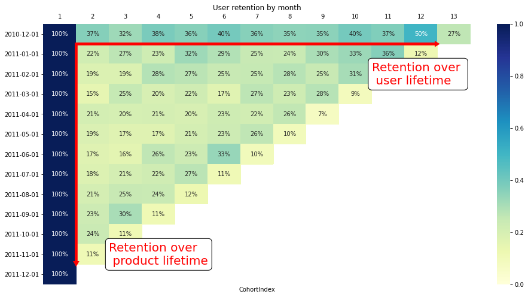

```python
# plotting a heatmap for customer retention
plt.figure(figsize  =(16,8))
plt.title('User retention by month')
# plt.axis('off')
sns.heatmap(data = retention, annot = True, fmt = '.0%', vmin = 0.0, vmax = 1, cmap = 'YlGnBu')
plt.annotate(s='Retention over \n user lifetime', xy=(12,10), xytext=(10,3),color = 'red', fontsize = 20,
            bbox=dict(boxstyle="round", fc="w"))
plt.annotate(s='Retention over\n product lifetime', xy=(0,10), xytext=(2,12),color = 'red', fontsize = 20,
             bbox=dict(boxstyle="round", fc="w"))

# create red arrows for x and y axes to show retention over user lifetime and product lifetime respectively
plt.arrow(1, 1, 11, 0, head_width= 0.1, head_length= 0.05, linewidth= 4, color= 'r', length_includes_head= True)
plt.arrow(1, 1, 0, 11, head_width= 0.07, head_length= 0.1, linewidth= 4, color= 'r', length_includes_head= True)
plt.tick_params(axis= 'both', which= 'major', labelsize= 10, labelbottom = False, bottom= False, top = False,
                labeltop= True)
plt.show()
```

Now, how do we infer from the triangular chart? It might look a little overwhelming at first, but we will see at two red arrows in the x and y axis to help us understand at the chart better. This chart has two main benefits:

**Retention over user lifetime**(depicted by horizontal arrow): will tell the long term relationship of any given cohort group. In the figure above, we are seeing at the cohorts activity (purchase) month-over-month. For each cohort we can see how many are coming back and how strong that cohort is. If we take the Dec 2010 cohort group,for example, we see how many people came to the site purchased in month 1, month 2, month 3 ...etc. In doing so we are following that cohort through their lifetime.

**Retention over product lifetime**(depicted by the vertical arrow): First thing on the left-hand side we are grouping customers by their purchase month starting Dec 2010 through Dec 2011. Here, we can compare different cohorts (group of customers) at the same stage in their life cycle. That would be looking down from top to bottom on the chart. For all the cohorts, what percentage are coming back to make purchases, say 3 months after their first purchase?

From the above chart we notice that fewer users stick around as time goes on. Also, we can see that Dec 2010 cohorts is the strongest. This will help us ask specific questions to that cohort group to know what is driving the customers to return back compared to other cohort groups after Jan 2011.

Similarly, we can extend the same analysis to show the average sales quantity for each cohort.

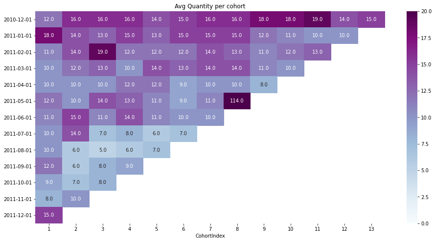

```python
cohort_avg = df.groupby(['CohortMonth', 'CohortIndex'])['Quantity'].mean()
cohort_avg = cohort_avg.reset_index()
avg_quantity = cohort_avg.pivot(index = 'CohortMonth', columns = 'CohortIndex', values = 'Quantity')
avg_quantity = avg_quantity.round(1)
avg_quantity.index = avg_quantity.index.date

# Creat a heatmap
plt.figure(figsize = (16, 8))
plt.title('Avg Quantity per cohort')
sns.heatmap(data = round(avg_quantity), annot = True, fmt = '0', vmin = 0.0, vmax = 20, cmap = 'BuPu')
plt.show()
```

Similary, we can compare how we are doing good in the quantity of items sold and customer satisfaction. Hopefully, we are selling more items so that would result in revenue increase and more customers are satified so that they become loyal. In the figure above, we can notice some average quantities in dark purple. This is can help us answer several specific questions about the quantity sold like are most of the purchases made by one customer? Or was there some promo discount that motivated some cutomers to buy more items. Is the total revenue from the items sold correlated with quantity? This kind of questions are helpful if we are looking to get to the bottom of any unsual customer shopping behaviour.

### Conclusion:

Hopefully, you have found this post usefull.

### Further reading:

**[Behavioral Analytics](https://www.investopedia.com/terms/b/behavioral-analytics.asp) Investopedia**

**[What is a cohort analysis?](https://www.quora.com/What-is-a-cohort-analysis) Quora**

**[Cohort Analysis](https://www.wikiwand.com/en/Cohort_analysis) Wikipedia**

**[Online Retail Data Set from UCI ML repo](https://archive.ics.uci.edu/ml/datasets/online+retail) UCI Repository**

TAGGED IN  
[Python](https://gafstar.github.io/tags/python/)

- [Share on Facebook](https://www.facebook.com/sharer/sharer.php?u=https%3A%2F%2Fgafstar.github.io%2F2021%2F06%2F22%2Fwhat-is-cohort-analysis%2F)
- [Share on Twitter](https://twitter.com/intent/tweet?text=https%3A%2F%2Fgafstar.github.io%2F2021%2F06%2F22%2Fwhat-is-cohort-analysis%2F)
- [Share on Google+](https://plus.google.com/share?url=https%3A%2F%2Fgafstar.github.io%2F2021%2F06%2F22%2Fwhat-is-cohort-analysis%2F)

[figure not shown]

#### Ghezae Fisseha

Data Science | Analytics | Business Intelligence

Data Scientist/Analytics

Redwood City, CA